# Regressions

# Regression Data

Distance from Eisenhower

```r
highway <- streets %>% filter(str_detect(DEDICATED_, "EISENHOWER EXPY"))

#Create distances from highway
buffer_distance <- 0.1*5280
highway_buffer_tenthtmile <- st_buffer(highway, dist = buffer_distance)
buffer_distance <- 0.25*5280
highway_buffer_quartmile <- st_buffer(highway, dist = buffer_distance)
buffer_distance <- 0.5*5280
highway_buffer_halfmile <- st_buffer(highway, dist = buffer_distance)
buffer_distance <- 1*5280
highway_buffer_1mile <- st_buffer(highway, dist = buffer_distance)


#Intersect with polygons
polygons_tenthmile_highway <- yearly_panel %>%
  filter(year == 1950) %>%
  dplyr::select(GRID_ID) %>%
  st_join(highway_buffer_tenthtmile, join = st_intersects, left = FALSE) %>%
  st_drop_geometry() %>%
  distinct(GRID_ID)

polygons_quartmile_highway <- yearly_panel %>%
  filter(year == 1950) %>%
  dplyr::select(GRID_ID) %>%
  st_join(highway_buffer_quartmile, join = st_intersects, left = FALSE) %>%
  st_drop_geometry() %>%
  distinct(GRID_ID)

polygons_halfmile_highway <- yearly_panel %>%
  filter(year == 1950) %>%
  dplyr::select(GRID_ID) %>%
  st_join(highway_buffer_halfmile, join = st_intersects, left = FALSE) %>%
  st_drop_geometry() %>%
  distinct(GRID_ID)

polygons_1_highway <- yearly_panel %>%
  filter(year == 1950) %>%
  dplyr::select(GRID_ID) %>%
  st_join(highway_buffer_1mile, join = st_intersects, left = FALSE) %>%
  st_drop_geometry() %>%
  distinct(GRID_ID)


#Create flags in data
reg_data <- yearly_panel %>%
  filter(year >= 1940 & year <= 1960) %>%
  mutate(flag_tenthmile_hway =
           ifelse(GRID_ID %in% c(polygons_tenthmile_highway$GRID_ID), 1, 0),
         flag_quartmile_hway =
           ifelse(GRID_ID %in% c(polygons_quartmile_highway$GRID_ID), 1, 0),
         flag_halfmile_hway =
           ifelse(GRID_ID %in% c(polygons_halfmile_highway$GRID_ID), 1, 0),
         flag_1mile_hway =
           ifelse(GRID_ID %in% c(polygons_1_highway$GRID_ID), 1, 0)) %>%
  mutate(flag_cat = case_when(flag_tenthmile_hway == 1 ~ "0.1 mile",
                              flag_quartmile_hway == 1 ~ "0.25 mile",
                              flag_halfmile_hway == 1 ~ "0.5 mile",
                              flag_1mile_hway == 1 ~ "1 mile",
                              TRUE ~ "> 1 mile")) %>%
  mutate(flag_constr = ifelse(year > 1949, 1, 0))


black_50 <- yearly_panel %>%
  st_drop_geometry() %>%
  filter(year == 1950) %>%
  mutate(flag_black_30 = ifelse(share_black > 0.3, 1, 0),
         flag_black_50 = ifelse(share_black > 0.5, 1, 0),
         flag_black_70 = ifelse(share_black > 0.7, 1, 0)) %>%
  dplyr::select(GRID_ID, flag_black_30, flag_black_50, flag_black_70)


reg_data <- reg_data %>%
  left_join(black_50)
```

Distance from Dan Ryan:

```r
highway <- streets %>% filter(str_detect(DEDICATED_, "DAN RYAN EXPY"))

#Create distances from highway
buffer_distance <- 0.1*5280
highway_buffer_tenthtmile <- st_buffer(highway, dist = buffer_distance)
buffer_distance <- 0.25*5280
highway_buffer_quartmile <- st_buffer(highway, dist = buffer_distance)
buffer_distance <- 0.5*5280
highway_buffer_halfmile <- st_buffer(highway, dist = buffer_distance)
buffer_distance <- 1*5280
highway_buffer_1mile <- st_buffer(highway, dist = buffer_distance)


#Intersect with polygons
polygons_tenthmile_highway <- yearly_panel %>%
  filter(year == 1950) %>%
  dplyr::select(GRID_ID) %>%
  st_join(highway_buffer_tenthtmile, join = st_intersects, left = FALSE) %>%
  st_drop_geometry() %>%
  distinct(GRID_ID)

polygons_quartmile_highway <- yearly_panel %>%
  filter(year == 1950) %>%
  dplyr::select(GRID_ID) %>%
  st_join(highway_buffer_quartmile, join = st_intersects, left = FALSE) %>%
  st_drop_geometry() %>%
  distinct(GRID_ID)

polygons_halfmile_highway <- yearly_panel %>%
  filter(year == 1950) %>%
  dplyr::select(GRID_ID) %>%
  st_join(highway_buffer_halfmile, join = st_intersects, left = FALSE) %>%
  st_drop_geometry() %>%
  distinct(GRID_ID)

polygons_1_highway <- yearly_panel %>%
  filter(year == 1950) %>%
  dplyr::select(GRID_ID) %>%
  st_join(highway_buffer_1mile, join = st_intersects, left = FALSE) %>%
  st_drop_geometry() %>%
  distinct(GRID_ID)


#Create flags in data
reg_data <- reg_data %>%
  mutate(flag_tenthmile_hway_danry =
           ifelse(GRID_ID %in% c(polygons_tenthmile_highway$GRID_ID), 1, 0),
         flag_quartmile_hway_danry =
           ifelse(GRID_ID %in% c(polygons_quartmile_highway$GRID_ID), 1, 0),
         flag_halfmile_hway_danry =
           ifelse(GRID_ID %in% c(polygons_halfmile_highway$GRID_ID), 1, 0),
         flag_1mile_hway_danry =
           ifelse(GRID_ID %in% c(polygons_1_highway$GRID_ID), 1, 0)) %>%
  mutate(flag_cat_danry = case_when(flag_tenthmile_hway_danry == 1 ~ "0.1 mile",
                              flag_quartmile_hway_danry == 1 ~ "0.25 mile",
                              flag_halfmile_hway_danry == 1 ~ "0.5 mile",
                              flag_1mile_hway_danry == 1 ~ "1 mile",
                              TRUE ~ "> 1 mile"))
```

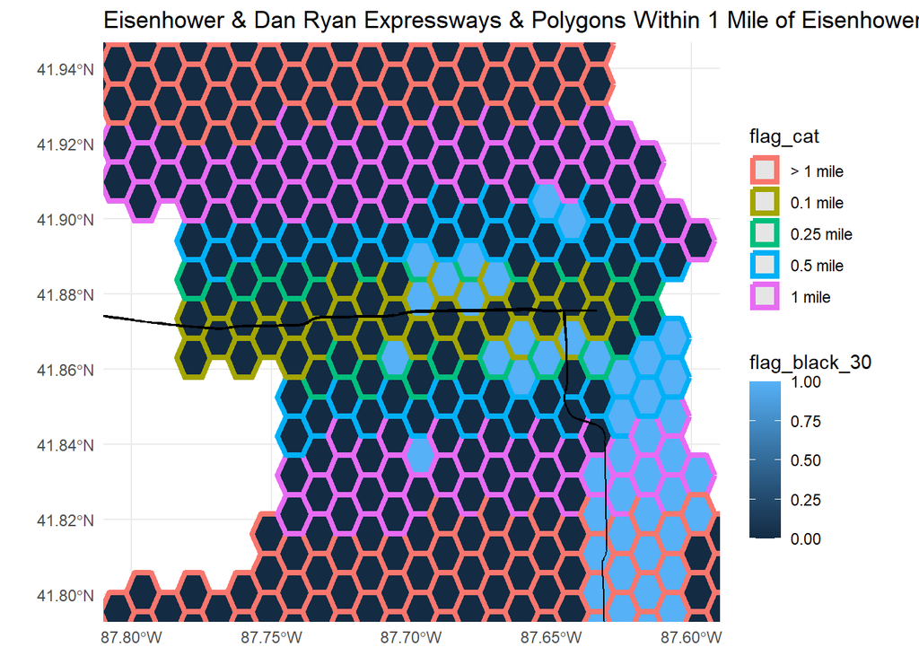

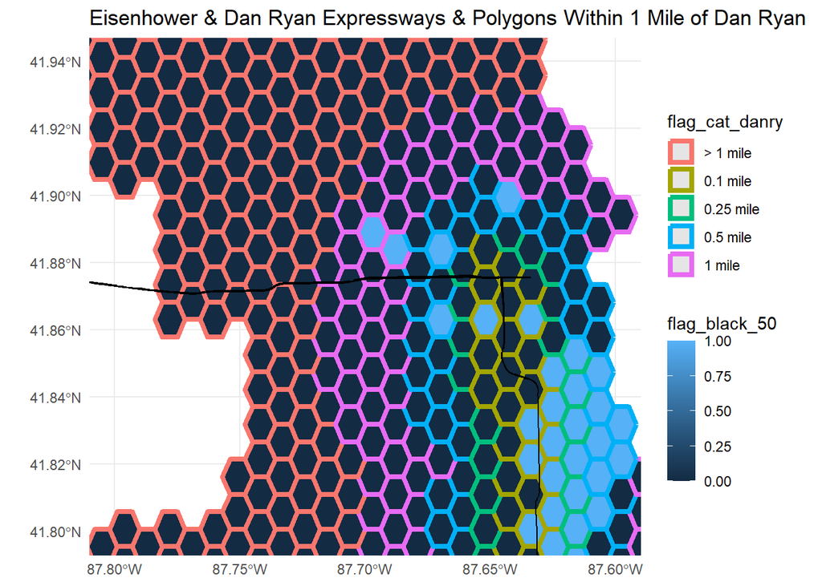

## Parallel Trends

### Chicago

Poisson parallel trends test, 1/10 mile vs Chicago:

```
## NOTE: 357/0 fixed-effects (7,497 observations) removed because of only 0 outcomes.
```

```
## GLM estimation, family = poisson, Dep. Var.: homicides
## Observations: 9,744
## Fixed-effects: GRID_ID: 464,  year: 21
## Standard-errors: Clustered (GRID_ID)
##                                 Estimate Std. Error   z value Pr(>|z|)
## year::1940:flag_tenthmile_hway  0.129297   0.330369  0.391372 0.695522
## year::1941:flag_tenthmile_hway -0.152784   0.277778 -0.550023 0.582304
## year::1942:flag_tenthmile_hway -0.540932   0.300042 -1.802854 0.071411 .
## year::1943:flag_tenthmile_hway -0.562911   0.429297 -1.311239 0.189777
## year::1944:flag_tenthmile_hway -0.365743   0.353656 -1.034175 0.301054
## year::1945:flag_tenthmile_hway -0.456575   0.276276 -1.652606 0.098411 .
## year::1946:flag_tenthmile_hway  0.175817   0.263464  0.667330 0.504561
## year::1947:flag_tenthmile_hway -0.007341   0.217683 -0.033724 0.973097
## year::1948:flag_tenthmile_hway  0.129297   0.212018  0.609841 0.541967
## year::1950:flag_tenthmile_hway  0.143482   0.246624  0.581783 0.560713
## year::1951:flag_tenthmile_hway  0.378895   0.257640  1.470642 0.141388
## year::1952:flag_tenthmile_hway  0.344152   0.199400  1.725936 0.084359 .
## year::1953:flag_tenthmile_hway  0.070359   0.207029  0.339854 0.733967
## year::1954:flag_tenthmile_hway  0.147657   0.242304  0.609387 0.542268
## year::1955:flag_tenthmile_hway  0.027721   0.223912  0.123803 0.901471
## year::1956:flag_tenthmile_hway  0.497961   0.248063  2.007401 0.044707 *
## year::1957:flag_tenthmile_hway  0.421376   0.266218  1.582824 0.113462
## year::1958:flag_tenthmile_hway  0.273099   0.235655  1.158893 0.246500
## year::1959:flag_tenthmile_hway  0.383155   0.226436  1.692108 0.090625 .
## year::1960:flag_tenthmile_hway  0.248842   0.210268  1.183455 0.236629
## ---
## Signif. codes:  0 '***' 0.001 '**' 0.01 '*' 0.05 '.' 0.1 ' ' 1
## Log-Likelihood: -6,380.2   Adj. Pseudo R2: 0.460962
##            BIC: 17,389.3     Squared Cor.: 0.666879
```

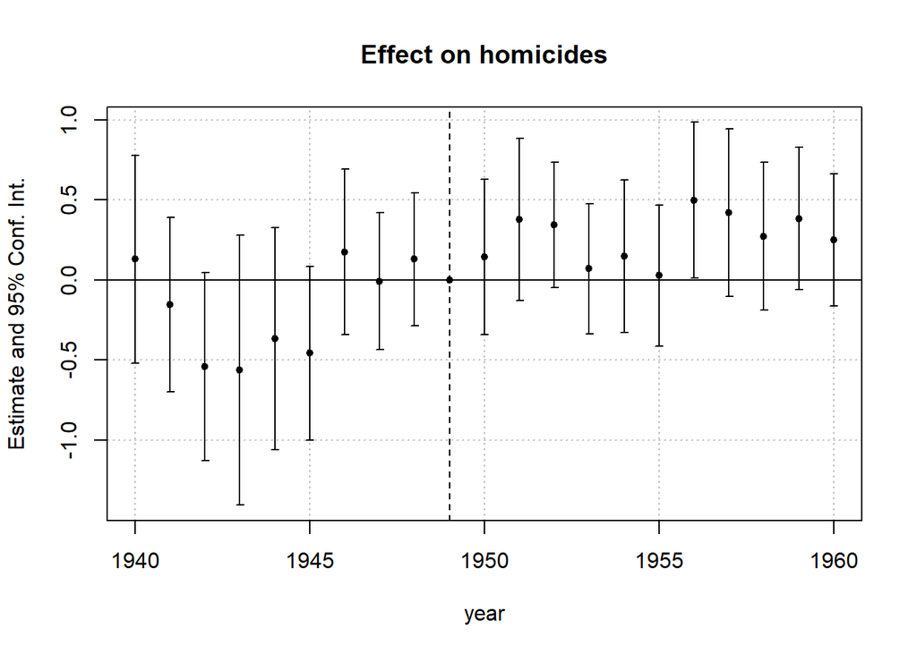

Poisson parallel trends test, 1/10 mile vs Chicago for Black Residency > 50%:

```
## NOTE: 12/0 fixed-effects (252 observations) removed because of only 0 outcomes.
```

```
## GLM estimation, family = poisson, Dep. Var.: homicides
## Observations: 882
## Fixed-effects: GRID_ID: 42,  year: 21
## Standard-errors: Clustered (GRID_ID)
##                                 Estimate Std. Error   z value   Pr(>|z|)
## year::1940:flag_tenthmile_hway  1.504077   0.274508  5.479181 4.2730e-08 ***
## year::1941:flag_tenthmile_hway  0.377294   0.157547  2.394798 1.6630e-02 *
## year::1942:flag_tenthmile_hway -0.007905   0.410585 -0.019253 9.8464e-01
## year::1943:flag_tenthmile_hway -1.004360   1.111151 -0.903891 3.6605e-01
## year::1944:flag_tenthmile_hway -1.312186   1.106206 -1.186204 2.3554e-01
## year::1945:flag_tenthmile_hway  0.325422   0.417628  0.779217 4.3585e-01
## year::1946:flag_tenthmile_hway  0.698452   0.337930  2.066855 3.8748e-02 *
## year::1947:flag_tenthmile_hway  0.314493   0.625588  0.502716 6.1516e-01
## year::1948:flag_tenthmile_hway -0.616186   0.623384 -0.988453 3.2293e-01
## year::1950:flag_tenthmile_hway  0.924259   0.746726  1.237748 2.1581e-01
## year::1951:flag_tenthmile_hway  1.022239   0.631417  1.618962 1.0546e-01
## year::1952:flag_tenthmile_hway  0.900542   0.393639  2.287738 2.2153e-02 *
## year::1953:flag_tenthmile_hway  0.298320   0.385603  0.773647 4.3914e-01
## year::1954:flag_tenthmile_hway  1.090707   0.396596  2.750175 5.9563e-03 **
## year::1955:flag_tenthmile_hway  1.022239   0.474326  2.155139 3.1151e-02 *
## year::1956:flag_tenthmile_hway  1.611708   0.249492  6.459948 1.0474e-10 ***
## year::1957:flag_tenthmile_hway  0.444305   0.174160  2.551133 1.0737e-02 *
## year::1958:flag_tenthmile_hway  0.568918   0.633470  0.898097 3.6913e-01
## year::1959:flag_tenthmile_hway  1.462113   0.200251  7.301395 2.8480e-13 ***
## year::1960:flag_tenthmile_hway  0.955864   0.202106  4.729527 2.2504e-06 ***
## ---
## Signif. codes:  0 '***' 0.001 '**' 0.01 '*' 0.05 '.' 0.1 ' ' 1
## Log-Likelihood: -1,391.9   Adj. Pseudo R2: 0.441839
##            BIC:  3,339.9     Squared Cor.: 0.71131
```

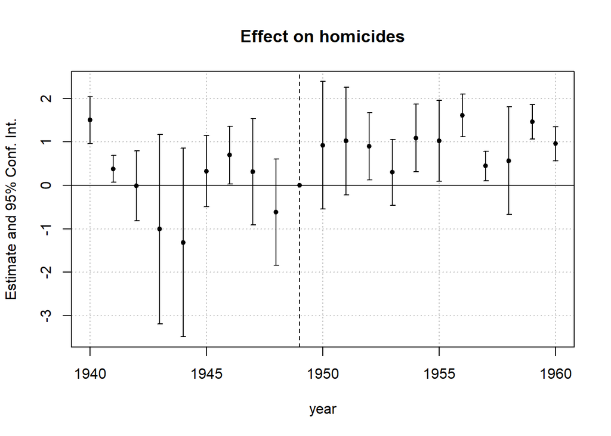

### 1 Mile from Eisenhower:

Poisson parallel trends test, 1/10 mile vs 1 mile from Eisenhower:

```
## NOTE: 41/0 fixed-effects (861 observations) removed because of only 0 outcomes.
```

```
## GLM estimation, family = poisson, Dep. Var.: homicides
## Observations: 3,318
## Fixed-effects: GRID_ID: 158,  year: 21
## Standard-errors: Clustered (GRID_ID)
##                                 Estimate Std. Error   z value Pr(>|z|)
## year::1940:flag_tenthmile_hway  0.009950   0.343718  0.028949 0.976905
## year::1941:flag_tenthmile_hway -0.061568   0.298901 -0.205982 0.836805
## year::1942:flag_tenthmile_hway -0.369082   0.355493 -1.038224 0.299166
## year::1943:flag_tenthmile_hway -0.406565   0.450723 -0.902027 0.367043
## year::1944:flag_tenthmile_hway -0.243140   0.375251 -0.647941 0.517023
## year::1945:flag_tenthmile_hway -0.419304   0.337518 -1.242316 0.214120
## year::1946:flag_tenthmile_hway  0.228842   0.298747  0.766006 0.443673
## year::1947:flag_tenthmile_hway -0.069377   0.254950 -0.272118 0.785531
## year::1948:flag_tenthmile_hway  0.022529   0.229277  0.098261 0.921725
## year::1950:flag_tenthmile_hway  0.031612   0.277057  0.114099 0.909160
## year::1951:flag_tenthmile_hway  0.342528   0.292380  1.171514 0.241392
## year::1952:flag_tenthmile_hway  0.304932   0.236366  1.290083 0.197022
## year::1953:flag_tenthmile_hway  0.229866   0.233112  0.986076 0.324096
## year::1954:flag_tenthmile_hway  0.267534   0.290403  0.921252 0.356919
## year::1955:flag_tenthmile_hway  0.099030   0.280398  0.353176 0.723956
## year::1956:flag_tenthmile_hway  0.609187   0.295207  2.063590 0.039057 *
## year::1957:flag_tenthmile_hway  0.565476   0.307664  1.837969 0.066067 .
## year::1958:flag_tenthmile_hway  0.437721   0.287172  1.524247 0.127447
## year::1959:flag_tenthmile_hway  0.555526   0.300757  1.847089 0.064734 .
## year::1960:flag_tenthmile_hway  0.389615   0.266553  1.461677 0.143830
## ---
## Signif. codes:  0 '***' 0.001 '**' 0.01 '*' 0.05 '.' 0.1 ' ' 1
## Log-Likelihood: -3,116.1   Adj. Pseudo R2: 0.422143
##            BIC:  7,837.5     Squared Cor.: 0.632686
```

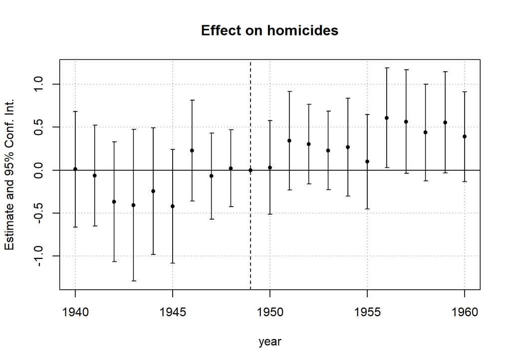

Poisson parallel trends test, 1/10 mile vs 1 mile from Eisenhower for Black Residency > 50%:

```
## NOTE: 2/0 fixed-effects (42 observations) removed because of only 0 outcomes.
```

```
## GLM estimation, family = poisson, Dep. Var.: homicides
## Observations: 336
## Fixed-effects: GRID_ID: 16,  year: 21
## Standard-errors: Clustered (GRID_ID)
##                                 Estimate Std. Error   z value   Pr(>|z|)
## year::1940:flag_tenthmile_hway  1.321756   0.311825  4.238769 2.2475e-05 ***
## year::1941:flag_tenthmile_hway  0.537637   0.242952  2.212934 2.6902e-02 *
## year::1942:flag_tenthmile_hway  0.172843   0.542759  0.318452 7.5014e-01
## year::1943:flag_tenthmile_hway -0.769520   1.195160 -0.643864 5.1966e-01
## year::1944:flag_tenthmile_hway -1.194403   1.190543 -1.003242 3.1574e-01
## year::1945:flag_tenthmile_hway  0.429563   0.565210  0.760005 4.4725e-01
## year::1946:flag_tenthmile_hway  0.795182   0.421867  1.884911 5.9442e-02 .
## year::1947:flag_tenthmile_hway  0.343907   0.688106  0.499788 6.1722e-01
## year::1948:flag_tenthmile_hway -0.729515   0.674891 -1.080937 2.7973e-01
## year::1950:flag_tenthmile_hway  0.810930   0.817980  0.991382 3.2150e-01
## year::1951:flag_tenthmile_hway  0.928713   0.695230  1.335836 1.8160e-01
## year::1952:flag_tenthmile_hway  0.900542   0.464565  1.938463 5.2567e-02 .
## year::1953:flag_tenthmile_hway  0.518794   0.432837  1.198590 2.3069e-01
## year::1954:flag_tenthmile_hway  1.198696   0.488014  2.456274 1.4039e-02 *
## year::1955:flag_tenthmile_hway  1.082864   0.550176  1.968213 4.9043e-02 *
## year::1956:flag_tenthmile_hway  1.840550   0.389196  4.729108 2.2551e-06 ***
## year::1957:flag_tenthmile_hway  0.677399   0.230293  2.941467 3.2666e-03 **
## year::1958:flag_tenthmile_hway  0.787400   0.709743  1.109415 2.6725e-01
## year::1959:flag_tenthmile_hway  2.014903   0.341373  5.902356 3.5835e-09 ***
## year::1960:flag_tenthmile_hway  1.147402   0.318239  3.605479 3.1158e-04 ***
## ---
## Signif. codes:  0 '***' 0.001 '**' 0.01 '*' 0.05 '.' 0.1 ' ' 1
## Log-Likelihood:  -628.2   Adj. Pseudo R2: 0.353509
##            BIC: 1,582.2     Squared Cor.: 0.676092
```

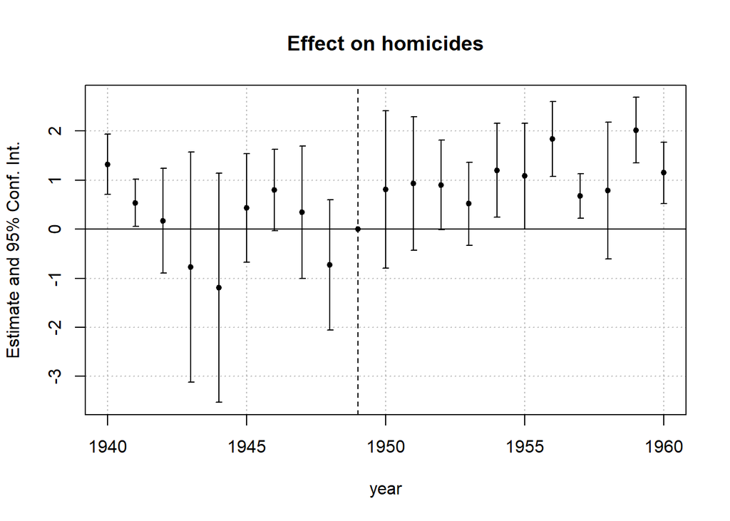

### Hexagons near Eisenhower and Dan Ryan:

Poisson parallel trends test, 1/10 mile vs 1 mile Eisenhower & 1 mile Dan Ryan :

```
## NOTE: 112/0 fixed-effects (2,352 observations) removed because of only 0 outcomes.
```

```
## GLM estimation, family = poisson, Dep. Var.: homicides
## Observations: 6,531
## Fixed-effects: GRID_ID: 311,  year: 21
## Standard-errors: Clustered (GRID_ID)
##                                 Estimate Std. Error   z value Pr(>|z|)
## year::1940:flag_tenthmile_hway  0.182322   0.331850  0.549410 0.582724
## year::1941:flag_tenthmile_hway -0.105361   0.280117 -0.376131 0.706820
## year::1942:flag_tenthmile_hway -0.491313   0.304104 -1.615608 0.106179
## year::1943:flag_tenthmile_hway -0.480748   0.431971 -1.112919 0.265743
## year::1944:flag_tenthmile_hway -0.315081   0.355968 -0.885139 0.376082
## year::1945:flag_tenthmile_hway -0.433865   0.280245 -1.548160 0.121584
## year::1946:flag_tenthmile_hway  0.162321   0.266855  0.608274 0.543006
## year::1947:flag_tenthmile_hway -0.003439   0.220114 -0.015625 0.987533
## year::1948:flag_tenthmile_hway  0.143406   0.213879  0.670502 0.502538
## year::1950:flag_tenthmile_hway  0.162119   0.249472  0.649849 0.515790
## year::1951:flag_tenthmile_hway  0.416364   0.261188  1.594115 0.110910
## year::1952:flag_tenthmile_hway  0.365856   0.202165  1.809692 0.070344 .
## year::1953:flag_tenthmile_hway  0.090850   0.209036  0.434615 0.663842
## year::1954:flag_tenthmile_hway  0.177703   0.245332  0.724334 0.468860
## year::1955:flag_tenthmile_hway  0.032509   0.228159  0.142485 0.886697
## year::1956:flag_tenthmile_hway  0.532910   0.251831  2.116143 0.034333 *
## year::1957:flag_tenthmile_hway  0.464554   0.269391  1.724458 0.084625 .
## year::1958:flag_tenthmile_hway  0.324920   0.239632  1.355912 0.175127
## year::1959:flag_tenthmile_hway  0.431297   0.232908  1.851789 0.064056 .
## year::1960:flag_tenthmile_hway  0.315372   0.213979  1.473847 0.140523
## ---
## Signif. codes:  0 '***' 0.001 '**' 0.01 '*' 0.05 '.' 0.1 ' ' 1
## Log-Likelihood: -5,246.1   Adj. Pseudo R2: 0.462314
##            BIC: 13,575.6     Squared Cor.: 0.667898
```

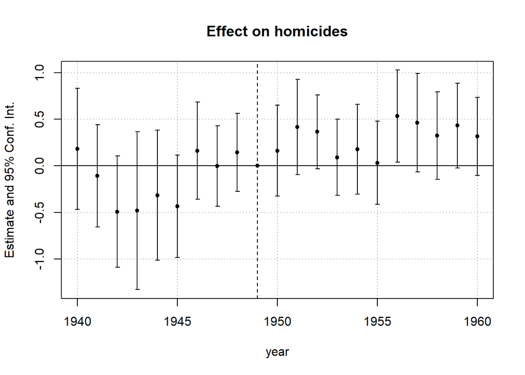

### Hexagons near Eisenhower and Dan Ryan with > 50% Black Residency in 1950:

Poisson parallel trends test, 1/10 mile vs 1 mile Eisenhower & 1 mile Dan Ryan all Black Residency > 50%:

```
## NOTE: 8/0 fixed-effects (168 observations) removed because of only 0 outcomes.
```

```
## GLM estimation, family = poisson, Dep. Var.: homicides
## Observations: 819
## Fixed-effects: GRID_ID: 39,  year: 21
## Standard-errors: Clustered (GRID_ID)
##                                 Estimate Std. Error   z value   Pr(>|z|)
## year::1940:flag_tenthmile_hway  1.504077   0.275270  5.464004 4.6551e-08 ***
## year::1941:flag_tenthmile_hway  0.377294   0.157985  2.388164 1.6933e-02 *
## year::1942:flag_tenthmile_hway -0.007905   0.411725 -0.019200 9.8468e-01
## year::1943:flag_tenthmile_hway -1.004360   1.114238 -0.901387 3.6738e-01
## year::1944:flag_tenthmile_hway -1.312186   1.109279 -1.182918 2.3684e-01
## year::1945:flag_tenthmile_hway  0.325422   0.418788  0.777058 4.3712e-01
## year::1946:flag_tenthmile_hway  0.698452   0.338869  2.061130 3.9291e-02 *
## year::1947:flag_tenthmile_hway  0.329092   0.627370  0.524558 5.9989e-01
## year::1948:flag_tenthmile_hway -0.610455   0.625139 -0.976512 3.2881e-01
## year::1950:flag_tenthmile_hway  0.930948   0.748870  1.243138 2.1382e-01
## year::1951:flag_tenthmile_hway  1.032092   0.633290  1.629731 1.0316e-01
## year::1952:flag_tenthmile_hway  0.924259   0.394842  2.340831 1.9241e-02 *
## year::1953:flag_tenthmile_hway  0.309073   0.386560  0.799549 4.2397e-01
## year::1954:flag_tenthmile_hway  1.098612   0.397828  2.761528 5.7532e-03 **
## year::1955:flag_tenthmile_hway  1.022239   0.475644  2.149169 3.1621e-02 *
## year::1956:flag_tenthmile_hway  1.623137   0.250612  6.476700 9.3750e-11 ***
## year::1957:flag_tenthmile_hway  0.454255   0.175040  2.595145 9.4551e-03 **
## year::1958:flag_tenthmile_hway  0.587787   0.635213  0.925338 3.5479e-01
## year::1959:flag_tenthmile_hway  1.475907   0.202135  7.301597 2.8437e-13 ***
## year::1960:flag_tenthmile_hway  0.955864   0.202667  4.716426 2.4002e-06 ***
## ---
## Signif. codes:  0 '***' 0.001 '**' 0.01 '*' 0.05 '.' 0.1 ' ' 1
## Log-Likelihood: -1,353.2   Adj. Pseudo R2: 0.419382
##            BIC:  3,236.3     Squared Cor.: 0.698914
```

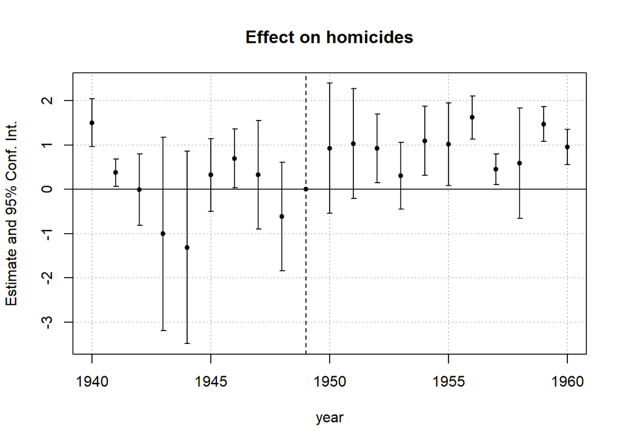

Poisson parallel trends test, 1/10 mile vs 1 mile Eisenhower & 1 mile Dan Ryan all Black Residency > 30%:

```
## NOTE: 11/0 fixed-effects (231 observations) removed because of only 0 outcomes.
```

```
## GLM estimation, family = poisson, Dep. Var.: homicides
## Observations: 1,239
## Fixed-effects: GRID_ID: 59,  year: 21
## Standard-errors: Clustered (GRID_ID)
##                                 Estimate Std. Error   z value   Pr(>|z|)
## year::1940:flag_tenthmile_hway  0.548566   0.395528  1.386920 0.16546605
## year::1941:flag_tenthmile_hway -0.397477   0.404264 -0.983211 0.32550370
## year::1942:flag_tenthmile_hway -0.491983   0.351297 -1.400475 0.16137100
## year::1943:flag_tenthmile_hway -0.822224   0.649878 -1.265198 0.20580026
## year::1944:flag_tenthmile_hway -1.070060   0.599858 -1.783856 0.07444714 .
## year::1945:flag_tenthmile_hway -0.565795   0.385574 -1.467408 0.14226498
## year::1946:flag_tenthmile_hway -0.064539   0.381735 -0.169066 0.86574440
## year::1947:flag_tenthmile_hway -0.038047   0.287882 -0.132161 0.89485671
## year::1948:flag_tenthmile_hway -0.007380   0.235705 -0.031311 0.97502174
## year::1950:flag_tenthmile_hway  0.156192   0.411881  0.379218 0.70452606
## year::1951:flag_tenthmile_hway  0.260884   0.384572  0.678375 0.49753405
## year::1952:flag_tenthmile_hway  0.565508   0.250508  2.257449 0.02398006 *
## year::1953:flag_tenthmile_hway  0.172106   0.299570  0.574509 0.56562310
## year::1954:flag_tenthmile_hway  0.395735   0.337226  1.173501 0.24059504
## year::1955:flag_tenthmile_hway  0.333379   0.336166  0.991709 0.32133935
## year::1956:flag_tenthmile_hway  0.965755   0.278359  3.469459 0.00052151 ***
## year::1957:flag_tenthmile_hway  0.444605   0.195409  2.275255 0.02289067 *
## year::1958:flag_tenthmile_hway  0.256843   0.329821  0.778735 0.43613566
## year::1959:flag_tenthmile_hway  0.712869   0.310587  2.295231 0.02171987 *
## year::1960:flag_tenthmile_hway  0.461213   0.247469  1.863719 0.06236119 .
## ---
## Signif. codes:  0 '***' 0.001 '**' 0.01 '*' 0.05 '.' 0.1 ' ' 1
## Log-Likelihood: -1,906.4   Adj. Pseudo R2: 0.419222
##            BIC:  4,517.9     Squared Cor.: 0.684302
```

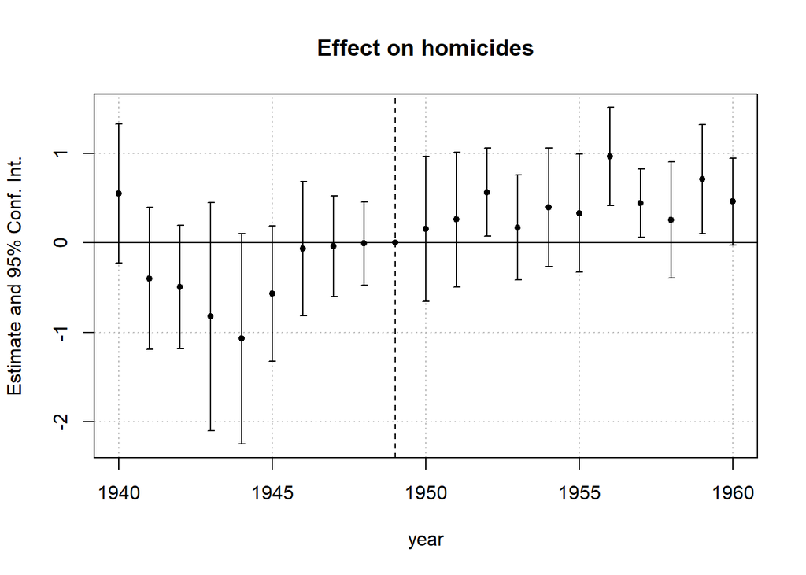